# VCFcheck

A tool for VCF files diagnostics

### Main features

- Input VCF file can be compressed (.gz) and uncompressed
- Tool adapted to work with multi-individual VCF and with VCF of only one individual
- Positions of the VCF can be SNPs, INDELS or ROHs
- Can filter the VCF by sample depth, mapping quality and missing data by SNP
- Can generate distribution plots of the missing data by SNP, the reference allele frequency and the sample depth by individual
- Can generate distribution plot of missing data by population, perform a PCA, test the Hardy-Weinberg equilibrium and generate the distribution plot of the inbreeding coefficient, if the VCF is multi-individual and the list of individuals and its populations is uploaded
- It allows to download the filtered VCF and the plots

### Requirements and execution

#### Pre-install:

1. Create virtual environment:

`conda create --name vcfcheck-app python=3.7`

2. Activate virtual environment:

`source vcfcheck-app/bin/activate`

3. Install dependencies:

`pip install -r requirements.txt`

#### Execute the program

1. Activate virtual environment:

`source vcfcheck-app/bin/activate`

2. Execute program:

`python VCFcheck.py`

3. Copy url on the web browser (http://0.0.0.0:8050/)

#### Exit from the virtual environment:

[output not shown]

[output not shown]

When the inputs are uploaded, the type of mutations to analyze must be selected before starting the analysis.

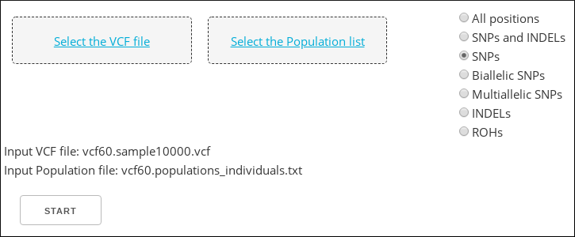

Then, the table from the VCF and a summary will be displayed. In that moment, it is possible to filter the file by sample depth, mapping quality or missing data using the corresponding sliders.

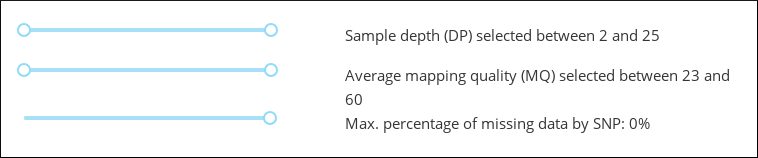

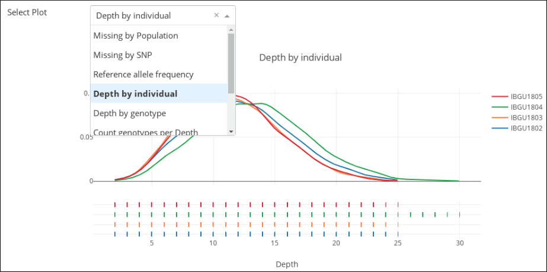